# Risk Factor Analysis

## Outcome Variable

**Outcome Variable:** swasted

## Predictor Variables

**Intervention Variable:** rain_quartile

**Adjustment Set:**

unadjusted

## Stratifying Variables

The analysis was stratified on these variable(s):

- studyid
- country
- agecat

## Data Summary

| studyid | country | agecat | rain_quartile | swasted | n_cell | n | outcome_variable |
| --- | --- | --- | --- | --- | --- | --- | --- |
| CMC-V-BCS-2002 | India | Birth | 1 | 0 | 17 | 86 | swasted |
| CMC-V-BCS-2002 | India | Birth | 1 | 1 | 0 | 86 | swasted |
| CMC-V-BCS-2002 | India | Birth | 2 | 0 | 22 | 86 | swasted |
| CMC-V-BCS-2002 | India | Birth | 2 | 1 | 0 | 86 | swasted |
| CMC-V-BCS-2002 | India | Birth | 3 | 0 | 28 | 86 | swasted |
| CMC-V-BCS-2002 | India | Birth | 3 | 1 | 0 | 86 | swasted |
| CMC-V-BCS-2002 | India | Birth | 4 | 0 | 18 | 86 | swasted |
| CMC-V-BCS-2002 | India | Birth | 4 | 1 | 1 | 86 | swasted |
| CMC-V-BCS-2002 | India | 6 months | 1 | 0 | 101 | 368 | swasted |
| CMC-V-BCS-2002 | India | 6 months | 1 | 1 | 1 | 368 | swasted |
| CMC-V-BCS-2002 | India | 6 months | 2 | 0 | 105 | 368 | swasted |
| CMC-V-BCS-2002 | India | 6 months | 2 | 1 | 4 | 368 | swasted |
| CMC-V-BCS-2002 | India | 6 months | 3 | 0 | 93 | 368 | swasted |
| CMC-V-BCS-2002 | India | 6 months | 3 | 1 | 4 | 368 | swasted |
| CMC-V-BCS-2002 | India | 6 months | 4 | 0 | 57 | 368 | swasted |
| CMC-V-BCS-2002 | India | 6 months | 4 | 1 | 3 | 368 | swasted |
| CMC-V-BCS-2002 | India | 24 months | 1 | 0 | 101 | 372 | swasted |
| CMC-V-BCS-2002 | India | 24 months | 1 | 1 | 0 | 372 | swasted |
| CMC-V-BCS-2002 | India | 24 months | 2 | 0 | 99 | 372 | swasted |
| CMC-V-BCS-2002 | India | 24 months | 2 | 1 | 0 | 372 | swasted |
| CMC-V-BCS-2002 | India | 24 months | 3 | 0 | 115 | 372 | swasted |
| CMC-V-BCS-2002 | India | 24 months | 3 | 1 | 2 | 372 | swasted |
| CMC-V-BCS-2002 | India | 24 months | 4 | 0 | 54 | 372 | swasted |
| CMC-V-BCS-2002 | India | 24 months | 4 | 1 | 1 | 372 | swasted |
| CMIN | Bangladesh | Birth | 1 | 0 | 4 | 19 | swasted |
| CMIN | Bangladesh | Birth | 1 | 1 | 0 | 19 | swasted |
| CMIN | Bangladesh | Birth | 2 | 0 | 4 | 19 | swasted |
| CMIN | Bangladesh | Birth | 2 | 1 | 1 | 19 | swasted |
| CMIN | Bangladesh | Birth | 3 | 0 | 5 | 19 | swasted |
| CMIN | Bangladesh | Birth | 3 | 1 | 0 | 19 | swasted |

[output cut: 506 more lines]

The following strata were considered:

- studyid: CMC-V-BCS-2002, country: India, agecat: 24 months
- studyid: CMC-V-BCS-2002, country: India, agecat: 6 months
- studyid: CMC-V-BCS-2002, country: India, agecat: Birth
- studyid: CMIN, country: Bangladesh, agecat: 24 months
- studyid: CMIN, country: Bangladesh, agecat: 6 months
- studyid: CMIN, country: Bangladesh, agecat: Birth
- studyid: CONTENT, country: Peru, agecat: 24 months
- studyid: CONTENT, country: Peru, agecat: 6 months
- studyid: CONTENT, country: Peru, agecat: Birth
- studyid: EE, country: Pakistan, agecat: 24 months
- studyid: EE, country: Pakistan, agecat: 6 months
- studyid: EE, country: Pakistan, agecat: Birth
- studyid: GMS-Nepal, country: Nepal, agecat: 24 months
- studyid: GMS-Nepal, country: Nepal, agecat: 6 months
- studyid: GMS-Nepal, country: Nepal, agecat: Birth
- studyid: Guatemala BSC, country: Guatemala, agecat: 6 months
- studyid: IRC, country: India, agecat: 24 months
- studyid: IRC, country: India, agecat: 6 months
- studyid: IRC, country: India, agecat: Birth
- studyid: JiVitA-3, country: Bangladesh, agecat: 24 months
- studyid: JiVitA-3, country: Bangladesh, agecat: 6 months
- studyid: JiVitA-3, country: Bangladesh, agecat: Birth
- studyid: JiVitA-4, country: Bangladesh, agecat: 24 months
- studyid: JiVitA-4, country: Bangladesh, agecat: 6 months
- studyid: JiVitA-4, country: Bangladesh, agecat: Birth
- studyid: Keneba, country: Gambia, agecat: 24 months
- studyid: Keneba, country: Gambia, agecat: 6 months
- studyid: Keneba, country: Gambia, agecat: Birth
- studyid: LCNI-5, country: Malawi, agecat: 24 months
- studyid: LCNI-5, country: Malawi, agecat: 6 months
- studyid: MAL-ED, country: Bangladesh, agecat: 24 months
- studyid: MAL-ED, country: Bangladesh, agecat: 6 months
- studyid: MAL-ED, country: Bangladesh, agecat: Birth
- studyid: MAL-ED, country: Brazil, agecat: 24 months
- studyid: MAL-ED, country: Brazil, agecat: 6 months
- studyid: MAL-ED, country: Brazil, agecat: Birth
- studyid: MAL-ED, country: India, agecat: 24 months
- studyid: MAL-ED, country: India, agecat: 6 months
- studyid: MAL-ED, country: India, agecat: Birth
- studyid: MAL-ED, country: Nepal, agecat: 24 months
- studyid: MAL-ED, country: Nepal, agecat: 6 months
- studyid: MAL-ED, country: Nepal, agecat: Birth
- studyid: MAL-ED, country: Peru, agecat: 24 months
- studyid: MAL-ED, country: Peru, agecat: 6 months
- studyid: MAL-ED, country: Peru, agecat: Birth
- studyid: MAL-ED, country: South Africa, agecat: 24 months
- studyid: MAL-ED, country: South Africa, agecat: 6 months
- studyid: MAL-ED, country: South Africa, agecat: Birth
- studyid: MAL-ED, country: Tanzania, agecat: 24 months
- studyid: MAL-ED, country: Tanzania, agecat: 6 months
- studyid: MAL-ED, country: Tanzania, agecat: Birth
- studyid: PROBIT, country: Belarus, agecat: 24 months
- studyid: PROBIT, country: Belarus, agecat: 6 months
- studyid: PROBIT, country: Belarus, agecat: Birth
- studyid: PROVIDE, country: Bangladesh, agecat: 24 months
- studyid: PROVIDE, country: Bangladesh, agecat: 6 months
- studyid: PROVIDE, country: Bangladesh, agecat: Birth
- studyid: ResPak, country: Pakistan, agecat: 6 months
- studyid: ResPak, country: Pakistan, agecat: Birth
- studyid: SAS-CompFeed, country: India, agecat: 6 months
- studyid: SAS-CompFeed, country: India, agecat: Birth
- studyid: SAS-FoodSuppl, country: India, agecat: 6 months
- studyid: TanzaniaChild2, country: Tanzania, agecat: 24 months
- studyid: TanzaniaChild2, country: Tanzania, agecat: 6 months
- studyid: ZVITAMBO, country: Zimbabwe, agecat: 24 months
- studyid: ZVITAMBO, country: Zimbabwe, agecat: 6 months
- studyid: ZVITAMBO, country: Zimbabwe, agecat: Birth

### Dropped Strata

Some strata were dropped due to rare outcomes:

- studyid: CMC-V-BCS-2002, country: India, agecat: Birth
- studyid: CMC-V-BCS-2002, country: India, agecat: 6 months
- studyid: CMC-V-BCS-2002, country: India, agecat: 24 months
- studyid: CMIN, country: Bangladesh, agecat: Birth
- studyid: CMIN, country: Bangladesh, agecat: 6 months
- studyid: CMIN, country: Bangladesh, agecat: 24 months
- studyid: CONTENT, country: Peru, agecat: Birth
- studyid: CONTENT, country: Peru, agecat: 6 months
- studyid: CONTENT, country: Peru, agecat: 24 months
- studyid: EE, country: Pakistan, agecat: Birth
- studyid: EE, country: Pakistan, agecat: 6 months
- studyid: EE, country: Pakistan, agecat: 24 months
- studyid: GMS-Nepal, country: Nepal, agecat: Birth
- studyid: GMS-Nepal, country: Nepal, agecat: 6 months
- studyid: GMS-Nepal, country: Nepal, agecat: 24 months
- studyid: Guatemala BSC, country: Guatemala, agecat: 6 months
- studyid: IRC, country: India, agecat: 6 months
- studyid: IRC, country: India, agecat: 24 months
- studyid: JiVitA-4, country: Bangladesh, agecat: Birth
- studyid: JiVitA-4, country: Bangladesh, agecat: 6 months
- studyid: Keneba, country: Gambia, agecat: 6 months
- studyid: Keneba, country: Gambia, agecat: 24 months
- studyid: LCNI-5, country: Malawi, agecat: 6 months
- studyid: LCNI-5, country: Malawi, agecat: 24 months
- studyid: MAL-ED, country: Bangladesh, agecat: Birth
- studyid: MAL-ED, country: Bangladesh, agecat: 6 months
- studyid: MAL-ED, country: Bangladesh, agecat: 24 months
- studyid: MAL-ED, country: Brazil, agecat: Birth
- studyid: MAL-ED, country: Brazil, agecat: 6 months
- studyid: MAL-ED, country: Brazil, agecat: 24 months
- studyid: MAL-ED, country: India, agecat: Birth
- studyid: MAL-ED, country: India, agecat: 6 months
- studyid: MAL-ED, country: India, agecat: 24 months
- studyid: MAL-ED, country: Nepal, agecat: Birth
- studyid: MAL-ED, country: Nepal, agecat: 6 months
- studyid: MAL-ED, country: Nepal, agecat: 24 months
- studyid: MAL-ED, country: Peru, agecat: Birth
- studyid: MAL-ED, country: Peru, agecat: 6 months
- studyid: MAL-ED, country: Peru, agecat: 24 months
- studyid: MAL-ED, country: South Africa, agecat: Birth
- studyid: MAL-ED, country: South Africa, agecat: 6 months
- studyid: MAL-ED, country: South Africa, agecat: 24 months
- studyid: MAL-ED, country: Tanzania, agecat: Birth
- studyid: MAL-ED, country: Tanzania, agecat: 6 months
- studyid: MAL-ED, country: Tanzania, agecat: 24 months
- studyid: PROBIT, country: Belarus, agecat: 6 months
- studyid: PROBIT, country: Belarus, agecat: 24 months
- studyid: PROVIDE, country: Bangladesh, agecat: Birth
- studyid: PROVIDE, country: Bangladesh, agecat: 6 months
- studyid: PROVIDE, country: Bangladesh, agecat: 24 months
- studyid: ResPak, country: Pakistan, agecat: Birth
- studyid: ResPak, country: Pakistan, agecat: 6 months
- studyid: SAS-CompFeed, country: India, agecat: Birth
- studyid: SAS-CompFeed, country: India, agecat: 6 months
- studyid: SAS-FoodSuppl, country: India, agecat: 6 months
- studyid: TanzaniaChild2, country: Tanzania, agecat: 6 months
- studyid: TanzaniaChild2, country: Tanzania, agecat: 24 months
- studyid: ZVITAMBO, country: Zimbabwe, agecat: 24 months

## Methods Detail

We’re interested in the causal parameters $E[Y_a]$ for all values of $a \in \mathcal{A}$. These parameters represent the mean outcome if, possibly contrary to fact, we intervened to set all units to have $A=a$. Under the randomization and positivity assumptions, these are identified by the statistical parameters $\psi_a=E_W[E_{Y|A,W}(Y|A=a,W)]$. In addition, we’re interested in the mean of $Y$, $E[Y]$ under no intervention (the observed mean). We will estimate these parameters by using SuperLearner to fit the relevant likelihood factors – $E_{Y|A,W}(Y|A=a,W)$ and $p(A=a|W)$, and then updating our likelihood fit using a joint TMLE.

For unadjusted analyses ($W=\{\}$), initial likelihoods were estimated using Lrnr_glm to estimate the simple $E(Y|A)$ and Lrnr_mean to estimate $p(A)$. For adjusted analyses, a small library containing Lrnr_glmnet, Lrnr_xgboost, and Lrnr_mean was used.

Having estimated these parameters, we will then use the delta method to estimate relative risks and attributable risks relative to a prespecified baseline level of $A$.

# Results Detail

## Results Plots

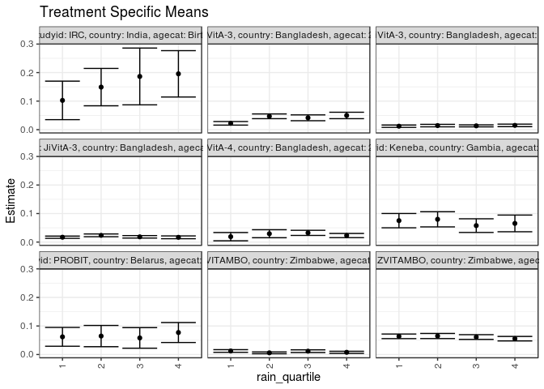

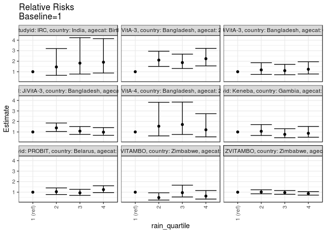

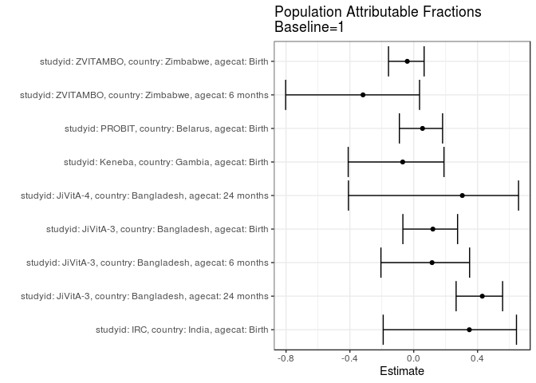

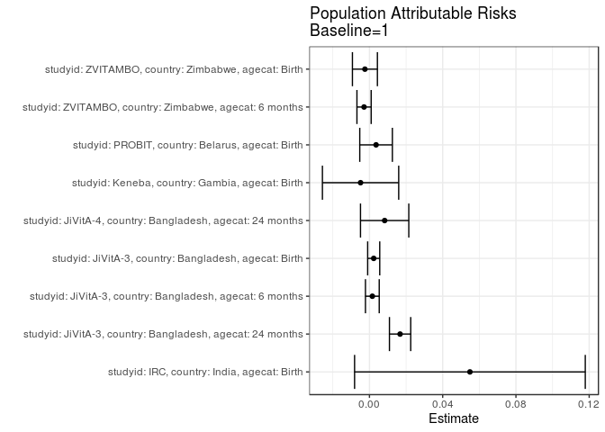

## Results Table

### Parameter: TSM

| studyid | country | agecat | intervention_level | baseline_level | estimate | ci_lower | ci_upper |
| --- | --- | --- | --- | --- | --- | --- | --- |
| IRC | India | Birth | 1 | NA | 0.1025641 | 0.0351370 | 0.1699912 |
| IRC | India | Birth | 2 | NA | 0.1491228 | 0.0836388 | 0.2146068 |
| IRC | India | Birth | 3 | NA | 0.1864407 | 0.0869182 | 0.2859631 |
| IRC | India | Birth | 4 | NA | 0.1956522 | 0.1144715 | 0.2768328 |
| JiVitA-3 | Bangladesh | Birth | 1 | NA | 0.0170022 | 0.0130464 | 0.0209579 |
| JiVitA-3 | Bangladesh | Birth | 2 | NA | 0.0235915 | 0.0188035 | 0.0283796 |
| JiVitA-3 | Bangladesh | Birth | 3 | NA | 0.0183747 | 0.0139876 | 0.0227619 |
| JiVitA-3 | Bangladesh | Birth | 4 | NA | 0.0167064 | 0.0118284 | 0.0215845 |
| JiVitA-3 | Bangladesh | 6 months | 1 | NA | 0.0121294 | 0.0080018 | 0.0162570 |
| JiVitA-3 | Bangladesh | 6 months | 2 | NA | 0.0142458 | 0.0099031 | 0.0185885 |
| JiVitA-3 | Bangladesh | 6 months | 3 | NA | 0.0133997 | 0.0098490 | 0.0169504 |
| JiVitA-3 | Bangladesh | 6 months | 4 | NA | 0.0149883 | 0.0105980 | 0.0193786 |
| JiVitA-3 | Bangladesh | 24 months | 1 | NA | 0.0222137 | 0.0159548 | 0.0284726 |
| JiVitA-3 | Bangladesh | 24 months | 2 | NA | 0.0467971 | 0.0385467 | 0.0550474 |
| JiVitA-3 | Bangladesh | 24 months | 3 | NA | 0.0415394 | 0.0313706 | 0.0517082 |
| JiVitA-3 | Bangladesh | 24 months | 4 | NA | 0.0497712 | 0.0385452 | 0.0609972 |
| JiVitA-4 | Bangladesh | 24 months | 1 | NA | 0.0189504 | 0.0044787 | 0.0334222 |
| JiVitA-4 | Bangladesh | 24 months | 2 | NA | 0.0293103 | 0.0153042 | 0.0433164 |
| JiVitA-4 | Bangladesh | 24 months | 3 | NA | 0.0323515 | 0.0233745 | 0.0413285 |
| JiVitA-4 | Bangladesh | 24 months | 4 | NA | 0.0228898 | 0.0155534 | 0.0302263 |
| Keneba | Gambia | Birth | 1 | NA | 0.0751174 | 0.0500791 | 0.1001557 |
| Keneba | Gambia | Birth | 2 | NA | 0.0798005 | 0.0532686 | 0.1063324 |
| Keneba | Gambia | Birth | 3 | NA | 0.0576923 | 0.0337315 | 0.0816531 |
| Keneba | Gambia | Birth | 4 | NA | 0.0654545 | 0.0362130 | 0.0946961 |
| PROBIT | Belarus | Birth | 1 | NA | 0.0619022 | 0.0289149 | 0.0948896 |
| PROBIT | Belarus | Birth | 2 | NA | 0.0646333 | 0.0273853 | 0.1018812 |
| PROBIT | Belarus | Birth | 3 | NA | 0.0581051 | 0.0220231 | 0.0941871 |
| PROBIT | Belarus | Birth | 4 | NA | 0.0770182 | 0.0420732 | 0.1119633 |
| ZVITAMBO | Zimbabwe | Birth | 1 | NA | 0.0637213 | 0.0556646 | 0.0717781 |
| ZVITAMBO | Zimbabwe | Birth | 2 | NA | 0.0647829 | 0.0558271 | 0.0737387 |
| ZVITAMBO | Zimbabwe | Birth | 3 | NA | 0.0611677 | 0.0529121 | 0.0694234 |
| ZVITAMBO | Zimbabwe | Birth | 4 | NA | 0.0554529 | 0.0475794 | 0.0633263 |
| ZVITAMBO | Zimbabwe | 6 months | 1 | NA | 0.0122411 | 0.0075644 | 0.0169177 |
| ZVITAMBO | Zimbabwe | 6 months | 2 | NA | 0.0059118 | 0.0027075 | 0.0091161 |
| ZVITAMBO | Zimbabwe | 6 months | 3 | NA | 0.0116633 | 0.0069243 | 0.0164022 |
| ZVITAMBO | Zimbabwe | 6 months | 4 | NA | 0.0076923 | 0.0040496 | 0.0113351 |

### Parameter: E(Y)

| studyid | country | agecat | intervention_level | baseline_level | estimate | ci_lower | ci_upper |
| --- | --- | --- | --- | --- | --- | --- | --- |
| IRC | India | Birth | NA | NA | 0.1574344 | 0.1188345 | 0.1960344 |
| JiVitA-3 | Bangladesh | Birth | NA | NA | 0.0193194 | 0.0169102 | 0.0217285 |
| JiVitA-3 | Bangladesh | 6 months | NA | NA | 0.0137035 | 0.0116269 | 0.0157801 |
| JiVitA-3 | Bangladesh | 24 months | NA | NA | 0.0389399 | 0.0346167 | 0.0432631 |
| JiVitA-4 | Bangladesh | 24 months | NA | NA | 0.0272439 | 0.0220352 | 0.0324527 |
| Keneba | Gambia | Birth | NA | NA | 0.0702592 | 0.0571716 | 0.0833469 |
| PROBIT | Belarus | Birth | NA | NA | 0.0655098 | 0.0324802 | 0.0985393 |
| ZVITAMBO | Zimbabwe | Birth | NA | NA | 0.0612419 | 0.0571066 | 0.0653771 |
| ZVITAMBO | Zimbabwe | 6 months | NA | NA | 0.0092887 | 0.0072498 | 0.0113275 |

### Parameter: RR

| studyid | country | agecat | intervention_level | baseline_level | estimate | ci_lower | ci_upper |
| --- | --- | --- | --- | --- | --- | --- | --- |
| IRC | India | Birth | 1 | 1 | 1.0000000 | 1.0000000 | 1.0000000 |
| IRC | India | Birth | 2 | 1 | 1.4539474 | 0.6594799 | 3.2055004 |
| IRC | India | Birth | 3 | 1 | 1.8177966 | 0.7794126 | 4.2395831 |
| IRC | India | Birth | 4 | 1 | 1.9076087 | 0.8767339 | 4.1505991 |
| JiVitA-3 | Bangladesh | Birth | 1 | 1 | 1.0000000 | 1.0000000 | 1.0000000 |
| JiVitA-3 | Bangladesh | Birth | 2 | 1 | 1.3875626 | 1.0410844 | 1.8493506 |
| JiVitA-3 | Bangladesh | Birth | 3 | 1 | 1.0807304 | 0.7694302 | 1.5179781 |
| JiVitA-3 | Bangladesh | Birth | 4 | 1 | 0.9826078 | 0.6829475 | 1.4137513 |
| JiVitA-3 | Bangladesh | 6 months | 1 | 1 | 1.0000000 | 1.0000000 | 1.0000000 |
| JiVitA-3 | Bangladesh | 6 months | 2 | 1 | 1.1744879 | 0.7423399 | 1.8582079 |
| JiVitA-3 | Bangladesh | 6 months | 3 | 1 | 1.1047303 | 0.7176905 | 1.7004948 |
| JiVitA-3 | Bangladesh | 6 months | 4 | 1 | 1.2357013 | 0.7837805 | 1.9481954 |
| JiVitA-3 | Bangladesh | 24 months | 1 | 1 | 1.0000000 | 1.0000000 | 1.0000000 |
| JiVitA-3 | Bangladesh | 24 months | 2 | 1 | 2.1066757 | 1.5037136 | 2.9514147 |
| JiVitA-3 | Bangladesh | 24 months | 3 | 1 | 1.8699893 | 1.3078080 | 2.6738328 |
| JiVitA-3 | Bangladesh | 24 months | 4 | 1 | 2.2405606 | 1.5581192 | 3.2219049 |
| JiVitA-4 | Bangladesh | 24 months | 1 | 1 | 1.0000000 | 1.0000000 | 1.0000000 |
| JiVitA-4 | Bangladesh | 24 months | 2 | 1 | 1.5466843 | 0.6255975 | 3.8239162 |
| JiVitA-4 | Bangladesh | 24 months | 3 | 1 | 1.7071648 | 0.7589434 | 3.8400913 |
| JiVitA-4 | Bangladesh | 24 months | 4 | 1 | 1.2078794 | 0.5333518 | 2.7354788 |
| Keneba | Gambia | Birth | 1 | 1 | 1.0000000 | 1.0000000 | 1.0000000 |
| Keneba | Gambia | Birth | 2 | 1 | 1.0623441 | 0.6634418 | 1.7010913 |
| Keneba | Gambia | Birth | 3 | 1 | 0.7680288 | 0.4509206 | 1.3081424 |
| Keneba | Gambia | Birth | 4 | 1 | 0.8713636 | 0.4990308 | 1.5214986 |
| PROBIT | Belarus | Birth | 1 | 1 | 1.0000000 | 1.0000000 | 1.0000000 |
| PROBIT | Belarus | Birth | 2 | 1 | 1.0441184 | 0.7775953 | 1.4019931 |
| PROBIT | Belarus | Birth | 3 | 1 | 0.9386593 | 0.6950380 | 1.2676737 |
| PROBIT | Belarus | Birth | 4 | 1 | 1.2441918 | 0.9603462 | 1.6119325 |
| ZVITAMBO | Zimbabwe | Birth | 1 | 1 | 1.0000000 | 1.0000000 | 1.0000000 |
| ZVITAMBO | Zimbabwe | Birth | 2 | 1 | 1.0166598 | 0.8429727 | 1.2261336 |
| ZVITAMBO | Zimbabwe | Birth | 3 | 1 | 0.9599259 | 0.7978471 | 1.1549301 |
| ZVITAMBO | Zimbabwe | Birth | 4 | 1 | 0.8702403 | 0.7195660 | 1.0524651 |
| ZVITAMBO | Zimbabwe | 6 months | 1 | 1 | 1.0000000 | 1.0000000 | 1.0000000 |
| ZVITAMBO | Zimbabwe | 6 months | 2 | 1 | 0.4829469 | 0.2488317 | 0.9373312 |
| ZVITAMBO | Zimbabwe | 6 months | 3 | 1 | 0.9528007 | 0.5454923 | 1.6642384 |
| ZVITAMBO | Zimbabwe | 6 months | 4 | 1 | 0.6284024 | 0.3419721 | 1.1547420 |

### Parameter: PAR

| studyid | country | agecat | intervention_level | baseline_level | estimate | ci_lower | ci_upper |
| --- | --- | --- | --- | --- | --- | --- | --- |
| IRC | India | Birth | 1 | NA | 0.0548703 | -0.0081266 | 0.1178672 |
| JiVitA-3 | Bangladesh | Birth | 1 | NA | 0.0023172 | -0.0009784 | 0.0056128 |
| JiVitA-3 | Bangladesh | 6 months | 1 | NA | 0.0015741 | -0.0021868 | 0.0053351 |
| JiVitA-3 | Bangladesh | 24 months | 1 | NA | 0.0167262 | 0.0109174 | 0.0225350 |
| JiVitA-4 | Bangladesh | 24 months | 1 | NA | 0.0082935 | -0.0048945 | 0.0214815 |
| Keneba | Gambia | Birth | 1 | NA | -0.0048582 | -0.0256874 | 0.0159711 |
| PROBIT | Belarus | Birth | 1 | NA | 0.0036075 | -0.0052956 | 0.0125107 |
| ZVITAMBO | Zimbabwe | Birth | 1 | NA | -0.0024795 | -0.0093001 | 0.0043411 |
| ZVITAMBO | Zimbabwe | 6 months | 1 | NA | -0.0029524 | -0.0068388 | 0.0009340 |

### Parameter: PAF

| studyid | country | agecat | intervention_level | baseline_level | estimate | ci_lower | ci_upper |
| --- | --- | --- | --- | --- | --- | --- | --- |
| IRC | India | Birth | 1 | NA | 0.3485280 | -0.1912582 | 0.6437248 |
| JiVitA-3 | Bangladesh | Birth | 1 | NA | 0.1199433 | -0.0679304 | 0.2747656 |
| JiVitA-3 | Bangladesh | 6 months | 1 | NA | 0.1148717 | -0.2054821 | 0.3500922 |
| JiVitA-3 | Bangladesh | 24 months | 1 | NA | 0.4295386 | 0.2655769 | 0.5568955 |
| JiVitA-4 | Bangladesh | 24 months | 1 | NA | 0.3044161 | -0.4091365 | 0.6566430 |
| Keneba | Gambia | Birth | 1 | NA | -0.0691463 | -0.4104797 | 0.1895851 |
| PROBIT | Belarus | Birth | 1 | NA | 0.0550686 | -0.0898947 | 0.1807508 |
| ZVITAMBO | Zimbabwe | Birth | 1 | NA | -0.0404863 | -0.1580045 | 0.0651058 |
| ZVITAMBO | Zimbabwe | 6 months | 1 | NA | -0.3178502 | -0.8024622 | 0.0364685 |